# Homework 01

Shuai Ding

9/17/2019

# 1. Create R Markdown notebook html document

# 2. Get some data

#### The name of my dataset

bechdel

#### Description

The raw data behind the story “The Dollar-And-Cents Case Against Hollywood’s Exclusion of Women” https://fivethirtyeight.com/features/the-dollar-and-cents-case-against-hollywoods-exclusion-of-women/.

#### Format

A data frame with 1794 rows representing movies and 15 variables:

#### Variable names and varable descriptions

| Variable name | Variable description |
| --- | --- |
| year | Year of release |
| imdb | Text to construct IMDB url. Ex: https://www.imdb.com/title/tt1711425 |
| title | Movie test |
| test | bechdel test result (detailed, with discrepancies indicated) |
| clean_test | bechdel test result (detailed): ok = passes test, dubious, men = women only talk about men, notalk = women don’t talk to each other, nowomen = fewer than two women |
| binary | Bechdel Test PASS vs FAIL binary |
| budget | Film budget |
| domgross | Domestic (US) gross |
| intgross | Total International (i.e., worldwide) gross |
| code | Bechdel Code |
| budget_2013 | Budget in 2013 inflation adjusted dollars |
| domgross_2013 | Domestic gross (US) in 2013 inflation adjusted dollars |
| intgross_2013 | Total International (i.e., worldwide) gross in 2013 inflation adjusted dollars |
| period_code | NULL |
| decade_code | NULL |

# 3. Show the data

#### Provide a simple summary of the data

```
##       year          imdb              title               test
##  Min.   :1970   Length:1794        Length:1794        Length:1794
##  1st Qu.:1998   Class :character   Class :character   Class :character
##  Median :2005   Mode  :character   Mode  :character   Mode  :character
##  Mean   :2003
##  3rd Qu.:2009
##  Max.   :2013
##
##    clean_test     binary              budget           domgross
##  nowomen:141   Length:1794        Min.   :  0.007   Min.   :  0.00
##  notalk :514   Class :character   1st Qu.: 12.000   1st Qu.: 16.31
##  men    :194   Mode  :character   Median : 28.000   Median : 42.19
##  dubious:142                      Mean   : 44.827   Mean   : 69.13
##  ok     :803                      3rd Qu.: 60.000   3rd Qu.: 93.35
##                                   Max.   :425.000   Max.   :760.51
##                                                     NA's   :17
##     intgross             code            budget_2013
##  Min.   :   0.0008   Length:1794        Min.   :  0.0086
##  1st Qu.:  26.1295   Class :character   1st Qu.: 16.0689
##  Median :  76.4825   Mode  :character   Median : 36.9958
##  Mean   : 150.3857                      Mean   : 55.4646
##  3rd Qu.: 189.8509                      3rd Qu.: 78.3379
##  Max.   :2783.9190                      Max.   :461.4359
##  NA's   :11
##  domgross_2013       intgross_2013       period_code    decade_code
##  Min.   :   0.0009   Min.   :   0.001   Min.   :1.00   Min.   :1.000
##  1st Qu.:  20.5466   1st Qu.:  33.233   1st Qu.:1.00   1st Qu.:1.000
##  Median :  55.9936   Median :  96.240   Median :2.00   Median :2.000
##  Mean   :  95.1748   Mean   : 197.838   Mean   :2.42   Mean   :1.937
##  3rd Qu.: 121.6784   3rd Qu.: 241.479   3rd Qu.:3.00   3rd Qu.:2.000
##  Max.   :1771.6828   Max.   :3171.931   Max.   :5.00   Max.   :3.000
##  NA's   :18          NA's   :11         NA's   :179    NA's   :179
```

#### Use the command datatable to show an interactive table

|  | Year | Imdb | FilmTitle | Test | Clean_test | Binary | Budget | DomesticGross | InternationalGross | BechdelCode | Budget_2013 | DomesticGross_2013 | InternationalGross_2013 | PeriodCode | DecadeCode |
| --- | --- | --- | --- | --- | --- | --- | --- | --- | --- | --- | --- | --- | --- | --- | --- |
| 1 | 2013 | tt1711425 | 21 &amp; Over | notalk | notalk | FAIL | 13 | 25.68238 | 42.195766 | 2013FAIL | 13 | 25.68238 | 42.195766 | 1 | 1 |
| 2 | 2012 | tt1343727 | Dredd 3D | ok-disagree | ok | PASS | 45 | 13.414714 | 40.868994 | 2012PASS | 45.658735 | 13.611086 | 41.467257 | 1 | 1 |
| 3 | 2013 | tt2024544 | 12 Years a Slave | notalk-disagree | notalk | FAIL | 20 | 53.107035 | 158.607035 | 2013FAIL | 20 | 53.107035 | 158.607035 | 1 | 1 |
| 4 | 2013 | tt1272878 | 2 Guns | notalk | notalk | FAIL | 61 | 75.61246 | 132.493015 | 2013FAIL | 61 | 75.61246 | 132.493015 | 1 | 1 |
| 5 | 2013 | tt0453562 | 42 | men | men | FAIL | 40 | 95.020213 | 95.020213 | 2013FAIL | 40 | 95.020213 | 95.020213 | 1 | 1 |
| 6 | 2013 | tt1335975 | 47 Ronin | men | men | FAIL | 225 | 38.362475 | 145.803842 | 2013FAIL | 225 | 38.362475 | 145.803842 | 1 | 1 |
| 7 | 2013 | tt1606378 | A Good Day to Die Hard | notalk | notalk | FAIL | 92 | 67.349198 | 304.249198 | 2013FAIL | 92 | 67.349198 | 304.249198 | 1 | 1 |
| 8 | 2013 | tt2194499 | About Time | ok-disagree | ok | PASS | 12 | 15.323921 | 87.324746 | 2013PASS | 12 | 15.323921 | 87.324746 | 1 | 1 |
| 9 | 2013 | tt1814621 | Admission | ok | ok | PASS | 13 | 18.007317 | 18.007317 | 2013PASS | 13 | 18.007317 | 18.007317 | 1 | 1 |
| 10 | 2013 | tt1815862 | After Earth | notalk | notalk | FAIL | 130 | 60.522097 | 244.373198 | 2013FAIL | 130 | 60.522097 | 244.373198 | 1 | 1 |

[output cut: 1784 more lines]

#### Add a non-interactive table using the kable function. Prettify the column names a bit.

High budget films

| Year | FilmTitle | Budget | DomesticGross | InternationalGross |
| --- | --- | --- | --- | --- |
| 2013 | 47 Ronin | 225 | 38.36248 | 145.8038 |
| 2013 | Man of Steel | 225 | 291.04552 | 687.9995 |
| 2013 | The Hobbit: The Desolation of Smaug | 250 | 257.39752 | 937.3975 |
| 2013 | The Lone Ranger | 275 | 89.28991 | 259.9899 |
| 2012 | John Carter | 275 | 73.05868 | 282.7781 |
| 2012 | The Amazing Spider-Man | 220 | 262.03066 | 757.8903 |
| 2012 | The Dark Knight Rises | 275 | 448.13910 | 1079.3439 |
| 2012 | The Hobbit: An Unexpected Journey | 250 | 303.00357 | 1014.7036 |
| 2011 | Pirates of the Caribbean: On Stranger Tides | 250 | 241.06387 | 1043.6639 |
| 2010 | Tangled | 260 | 200.82194 | 586.5819 |
| 2009 | Avatar | 425 | 760.50762 | 2783.9190 |
| 2009 | Harry Potter and the Half-Blood Prince | 250 | 301.95920 | 934.4165 |
| 2008 | Quantum of Solace | 230 | 169.36843 | 591.6921 |
| 2008 | The Chronicles of Narnia: Prince Caspian | 225 | 141.62149 | 419.4903 |
| 2007 | Pirates of the Caribbean: At World’s End | 300 | 309.42043 | 960.9965 |
| 2006 | Pirates of the Caribbean: Dead Man’s Chest | 225 | 423.31581 | 1060.6158 |
| 2006 | Superman Returns | 232 | 200.12000 | 390.8740 |

# 4. Add some Latex formulas

Data on budget and gross income of films were given to predict the prominence of women in those films, which were featured by whether a film has one conversation between two women about something rather than men. The binary logistic regression model is utilized to model the result of the Bechdel test. The formula is shown as follows:
$$h_{\theta }(x) = \frac{1}{1 +e^{-\theta ^{T}x}}$$
This logistic model has two possible values: pass/fail.

# 5. Add a plot

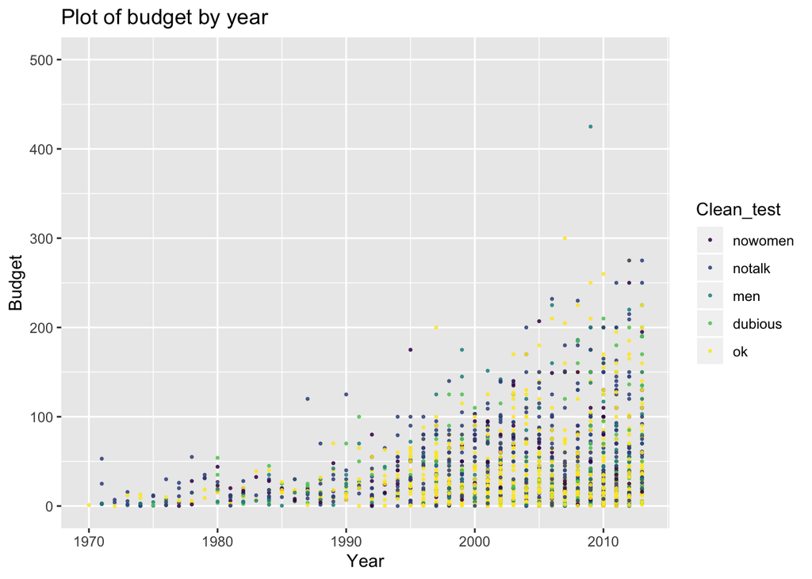

# 6. Add a picture

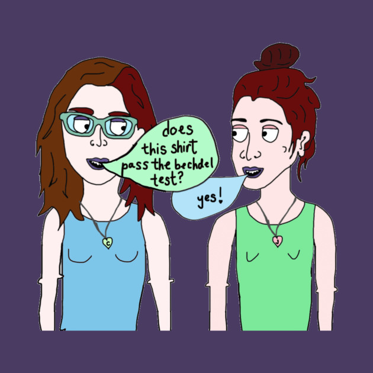

Funny picture about the Bechdel test

- The Bechdel test is the easiest test in the world!

# 7. More Markdown

#### Add a footnote [^1]

#### Add a block quote

> “She goes on to say that it isn’t surprising that Frozen passed the Bechdel Test considering its two main characters are female. In fact there are, many other Disney movies pass the Bechdel Test with flying colors.”
[^1]: The Bechdel test website: https://fivethirtyeight.com/features/the-dollar-and-cents-case-against-hollywoods-exclusion-of-women/